# Linux 入门教程

2017年9月18日

## Linux发展历史

Linux操作系统是UNIX操作系统的一种克隆系统。它诞生于1991年的10月5日，由芬兰大学生林**纳斯·托瓦兹**和后来加入的众多爱好者共同完成。

[figure not shown]

## Linux发行版本

Linux 发行版 (也被叫做 GNU/Linux发行版)是基于Linux内核的类Unix操作系统。Linux发行版通常包含了包括桌面环境、办公包、媒体播放器、数据库等应用软件。这些操作系统通常由Linux内核、以及来自GNU计划的大量的软件、函数库，和基于XWindow的图形界面组成。现在世界上已经有超过300个Linux发行版了。

[figure not shown]

## Linux系统组成

- **系统内核**  
  内核是操作系统的核心，与硬件通讯，实现最基本的功能。
- **shell**  
  shell是系统的用户界面，提供了用户与内核进行交互操作的一种接口。它接收用户输入的命令并把它送入内核去执行，是一个命令解释器。shell有自己的编程语言。
- **文件系统**  
  文件系统是文件存放在磁盘等存储设备上的组织方法。
- **应用程序**  
  标准的Linux系统一般都有一套都有称为应用程序的程序集，它包括文本编辑器、编程语言、XWindow、办公套件、Internet工具和数据库等。

## shell种类

目前流行的shell有ash、bash、ksh、csh、zsh等，不同的shell都有自己的特点以及用途。

查看自己使用的是哪一种shell，在终端输入：

```r
echo $SHELL
```

执行结果：

```r
/bin/bash
```

**bash**全名是Bourne Again Shell，一共有40个命令。所以一般的shell脚本都会指定它为执行路径。如一般shell脚本的第一行会如下：

```r
#！/bin/bash
```

## 终端（Terminal）

linux 的终端就是控制台， 是用户与内核交互的平台， 通过输入指令来控制内核完成任务操作。

[figure not shown]

## Command line

命令行之前通常有一个提示符

```r
1. usr@bash: ls -l /home/ryan
2. total 3
3. drwxr-xr-x  2 ryan users 4096 Mar 23 13:34 bin
4. drwxr-xr-x 18 ryan users 4096 Feb 17 09:12 Documents
5. drwxr-xr-x  2 ryan users 4096 May 05 17:25 public_html
6. usr@bash:
```

## pwd

打印工作目录：

```r
1. usr@bash: pwd
2. /home/ryan
3. usr@bash:
```

个性化设置命令行提示符（高亮显示工作路径）：

在'~/.bash_profile'文件中加入以下代码并source：

```r
export PS1='[\u@\h]\[\e[1;32m\]`pwd`\n\$\[\e[0;37;40m\]'
```

效果如下：

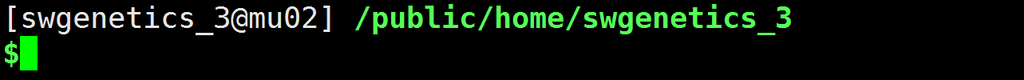

## ls

列出当前目录下有哪些内容